# Homework #4 - Calculating the SCC

Daija Odom, Devon Rossi, and Logan Ossentjuk

5/16/2022

```r
# Read in the data
damages_data <- read_csv(here("data","damages.csv"))
warming_data <- read_csv(here("data", "warming.csv"))
```

## Question 1.

#### Using the damages.csv, estimate a quadratic damage function relating the dollar value of damages to the change in global mean temperature. Estimate a model with zero intercept because damages by construction must equal zero when there is no climate change. Plot your estimated damage function, overlaid with a scatterplot of the underlying data.

#### The following equation is plotted below:

$$Damages = -1.06 * 10^{12} (warming) + 1.93*10^{13} (warming^2)$$

```r
# Create a linear regression model
damages_data$warming_squared <- damages_data$warming^2
quad_damage_model <- lm(damages ~ warming + warming_squared+ 0, data = damages_data)
# summary(quad_damage_model)

# Define function
quad_function <- function(warming){
  harm <- quad_damage_model$coefficients[1]*warming + quad_damage_model$coefficients[2]*warming^2
  return(harm)
}
```

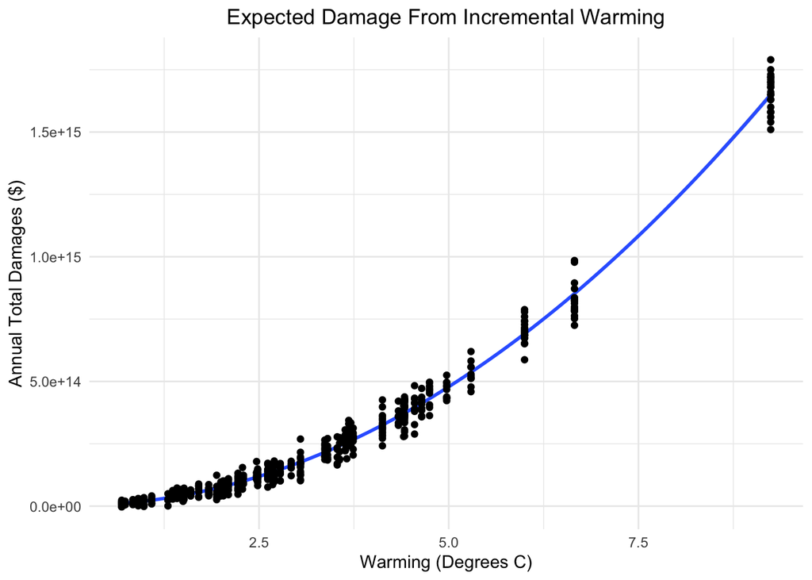

**Figure 1.** Total Annual Damages ($) from each Degree of Celcious Increase due to climate change fitted with quadratic function and zero intercept

```r
# Create a function and scatter plot graph for damages. Use geom_smooth to create quadratic fit.
ggplot(quad_damage_model, aes(warming, damages)) +
  geom_smooth(method = "lm", formula = y ~ x + I(x^2)) +
  geom_point() +
  theme_minimal() +
  labs(title = 'Expected Damage From Incremental Warming',x = "Warming (Degrees C)", y = "Annual Total Damages ($)") +
theme(plot.title = element_text(hjust = 0.5))
```

## Question 2.

#### Use warming.csv and your estimated damage function to predict damages in each year under the baseline climate and the pulse scenario. Make four plots:

```r
# Create columns of warming with damages for warming baseline, pulse, the difference between no pulse (warming baseline) and pulse, and the difference in damages per ton CO2.

## Warming baseline
warming_data$baseline_damage <- quad_function(warming_data$warming_baseline)

## Pulse
warming_data$pulse_damage <- quad_function(warming_data$warming_pulse)

## Difference
warming_data$difference <- warming_data$pulse_damage - warming_data$baseline_damage

## Difference in damages per ton
warming_data$damage_per_ton_CO2 <-warming_data$difference/35e9
```

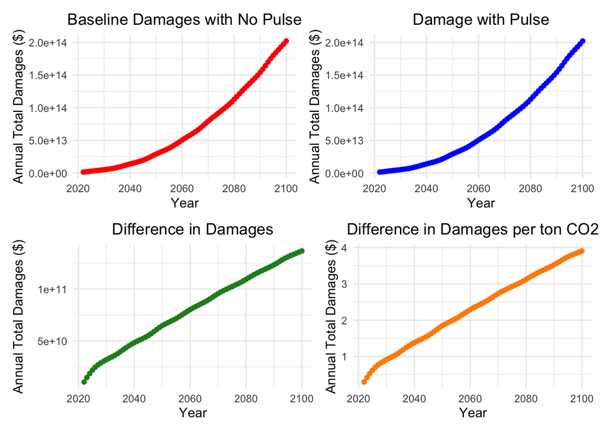

```r
## (1) Damages over time without the pulse**
p1 <- ggplot(data = warming_data) +
  geom_point(aes(x = year, y = baseline_damage), color = "red") +
  labs(title = "Baseline Damages with No Pulse",
       x = "Year",
       y = "Annual Total Damages ($)") +
  theme_minimal()  +
  theme(plot.title = element_text(hjust = 0.5))

## (2) Damages over time with the pulse**
p2 <- ggplot(data = warming_data) +
  geom_point(aes(x = year, y = pulse_damage), color = 'blue') +
  labs(title = "Damage with Pulse",
       x = "Year",
       y = "Annual Total Damages ($)") +
  theme_minimal()  +
  theme(plot.title = element_text(hjust = 0.5))
## (3) The difference in damages over time that arrive from pulse**
p3 <- ggplot(data = warming_data) +
  geom_point(aes(x = year, y = difference), color = "forestgreen") +
  labs(title = "Difference in Damages",
       x = "Year",
       y = "Annual Total Damages ($)") +
  theme_minimal()  +
  theme(plot.title = element_text(hjust = 0.5))
## (4) The difference in damages over time from the pulse *per ton of CO_2_* (you can assume that each ton of the pulse causes the same amount of damage)**
p4 <- ggplot(data = warming_data) +
  geom_point(aes(x = year, y = damage_per_ton_CO2), color = "darkorange") +
  labs(title = "Difference in Damages per ton CO2",
       x = "Year",
       y = "Annual Total Damages ($)") +
  theme_minimal()  +
  theme(plot.title = element_text(hjust = 0.5))

all_plots <- (p1 | p2) / (p3 | p4)

all_plots
```

**Figure 2.** Differing damage results under pulse and no pulse scenarios displaying the Annual Total Damages over Time.

## Question 3.

#### The SCC is the present discounted value of the stream of future damages caused by one additional ton of CO_2_. The Obama Administration used a discount rate of 3% to discount damages. Recently, New York State used a discount rate of 2%. Calculate and make a plot of the SCC (y-axis) against the discount rate (x-axis) for a reasonable range of discount rates. Explain the intuition for how the discount rate affects the SCC.

```r
# Make a function of npv
npv_function <- function(future_damage, year, rate, reference_year) {
  output = future_damage/(1+rate/100)^(year-reference_year)
  return(output)
}

# Create columns for discount rates of 2%-10%
npv_damages_df <- data.frame(year = warming_data$year) %>%
  mutate(damage_per_ton_CO2 = warming_data$damage_per_ton_CO2,
         discounted_2_percent = npv_function(damage_per_ton_CO2, year, 2, 2022),
         discounted_3_percent = npv_function(damage_per_ton_CO2, year, 3, 2022),
         discounted_4_percent = npv_function(damage_per_ton_CO2, year, 4, 2022),
         discounted_5_percent = npv_function(damage_per_ton_CO2, year, 5, 2022),
         discounted_6_percent = npv_function(damage_per_ton_CO2, year, 6, 2022),
         discounted_7_percent = npv_function(damage_per_ton_CO2, year, 7, 2022),
         discounted_8_percent = npv_function(damage_per_ton_CO2, year, 8, 2022),
         discounted_9_percent = npv_function(damage_per_ton_CO2, year, 9, 2022),
         discounted_10_percent = npv_function(damage_per_ton_CO2, year, 10, 2022))


# Create a new data frame (total damages) which sums the individual discount rates from 2% - 10%
total_damages_df <- data.frame(rates = c(2:10), total_discount_sum = c(sum(npv_damages_df$discounted_2_percent),
                                                                       sum(npv_damages_df$discounted_3_percent),
                                                                       sum(npv_damages_df$discounted_4_percent),
                                                                       sum(npv_damages_df$discounted_5_percent),
                                                                       sum(npv_damages_df$discounted_6_percent),
                                                                       sum(npv_damages_df$discounted_7_percent),
                                                                       sum(npv_damages_df$discounted_8_percent),
                                                                       sum(npv_damages_df$discounted_9_percent),
                                                                       sum(npv_damages_df$discounted_10_percent)))
```

#### As shown below, as the discount rate increases, the net present value (NPV) decreases non-linearly as exponential decay.

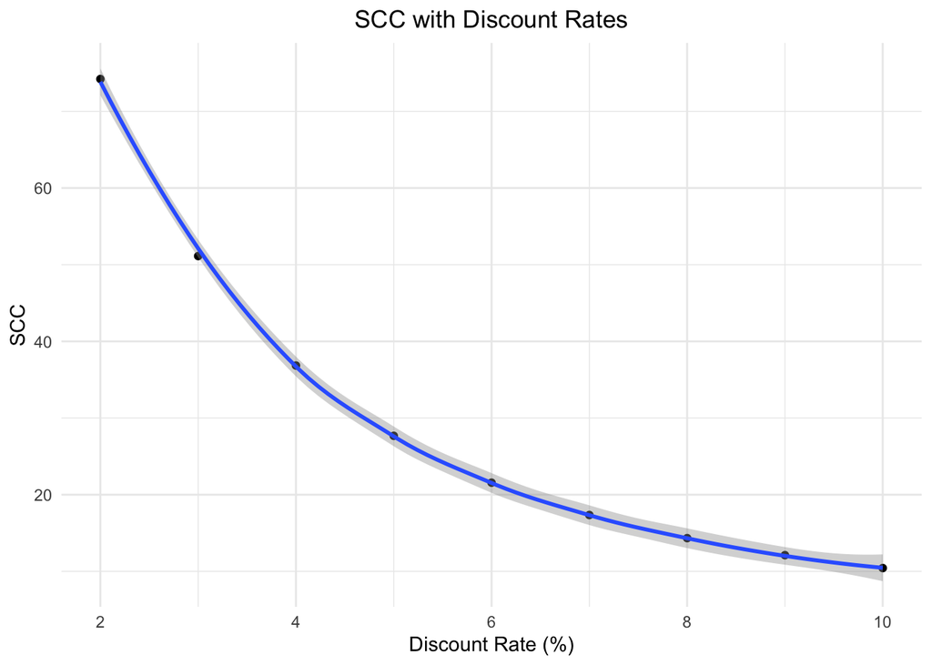

```r
## Visualizing the SCC with Discount Rates from 2-10%
ggplot(data = total_damages_df) +
  geom_point(aes(x=rates, y=total_discount_sum)) +
  geom_smooth(aes(x=rates, y=total_discount_sum)) +
  labs(title = "SCC with Discount Rates",
       x = "Discount Rate (%)",
       y = "SCC") +
  theme_minimal() +
  theme(plot.title = element_text(hjust = 0.5))
```

**Figure 3.** Social Cost of Carbon (SCC) versus differing discount rates from 2-10%.

## Question 4.

#### The National Academies of Sciences, Engineering, and Medicine advised the government in a 2017 report to use the Ramsey Rule when discounting within the SCC calculation:

$$r = ρ + ηg$$

##### Using ρ = 0.001, η = 2, and g = 0.01, the SCC is calculated below and located in red on the graph below

```r
p <- 0.001
n <- 2
g <- 0.01

ramsey_rule_equation <- (p + n*g)*100

#Ramsey rule = 2.1
#ramsey rule = 2.1%

ramsey_df <- data.frame()


# plug into previous equation and sum to find SCC
# x-axis
ramsey_damages <- npv_function(npv_damages_df$damage_per_ton_CO2, npv_damages_df$year, ramsey_rule_equation, 2022)

# y-axis
ramsey_discount_damages <- sum(ramsey_damages)
```

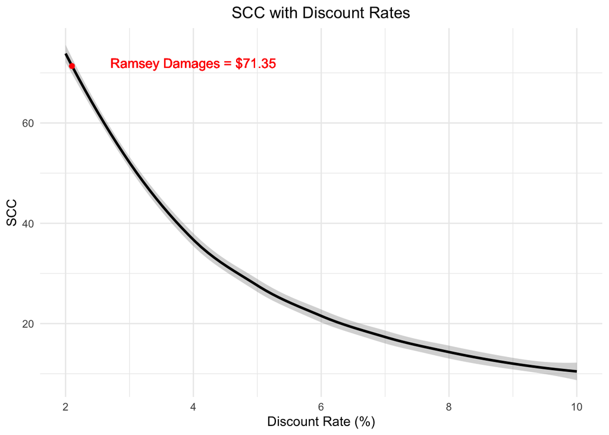

```r
# Plot the new point (shown in blue)
ggplot(data = total_damages_df) +
  geom_smooth(aes(x=rates, y=total_discount_sum), color = 'black') +
  geom_point(x = ramsey_rule_equation, y = ramsey_discount_damages, color = "red")+
  geom_text(aes(x = 4, y = 72, label = "Ramsey Damages = $71.35"), color = "red") +
  # scale_y_continuous(limits = c(0,70)) +
  # scale_x_continuous(limits = c(2,10)) +
  labs(title = "SCC with Discount Rates",
       x = "Discount Rate (%)",
       y = "SCC") +
  theme_minimal() +
  theme(plot.title = element_text(hjust = 0.5))
```

**Figure 4.** Social Cost of Carbon (SCC) versus differing discount rates from 2-10%. SCC value found utilizing the Ramsey Rule is displayed in red ($71.35).

## Question 5.

#### Now suppose there are two possible climate policies that can be pursued. Policy A is business as usual and Policy B is to take immediate and strong action on climate change. Use these facts:

#### * If you undertake Policy A there are two possible outcomes. Either warming will occur as in the “baseline” (i.e. “no pulse”) dataset above (this happens with probability 0.5) or warming each year will be 1.5 times in the “baseline” dataset (with probability 0.5).

#### * Under Policy B, warming will continue until 2050 as in the “baseline” dataset, and then will stabilize at 1.29 degrees and stay that way forever.

#### * Society is risk neutral

#### * Use a discount rate of 2%

#### What is the expected present value of damages up to 2100 under Policy A? What is the expected present value of damages up to 2100 under Policy B? Suppose undertaking Policy A costs zero and undertaking Policy B costs X. The total cost of a policy is the implementation cost plus expected damages. Make a plot of total cost of Policy A and total cost of Policy B against X. Suppose Congress wants to undertake the policy with the lower total cost. Use your graph to advise Congress.

### Policy A

Expected present value for the business as usual scenario under Policy A up to 2100 were found to be $2.10*10^{15}$ dollars

### Policy B

```r
discount_rate <- 2

warming_policy <- warming_data %>%
  mutate(policy_a1 = warming_baseline,
         policy_a2 = 1.5*warming_baseline,
         policy_b = ifelse(year < 2050, policy_a2, 1.29)) %>%
  mutate(damages_a = quad_function(policy_a2)) %>%
  mutate(damages_b = quad_function(policy_b)) %>%
  mutate(future_years = year-2022) %>%
  mutate(discount_policy_a2 = damages_a/(1.02^future_years)) %>%
  mutate(discount_policy_b = damages_b/(1.02^future_years)) %>%
  mutate(discount_damages_bau = warming_baseline/1.02^future_years)

#Expected value of damages for policy a and b given probability of 0.5 for policy a and certainty for policy b
prob_policy_a <- 0.5*sum(warming_policy$discount_policy_a2) + 0.5*sum(warming_policy$discount_damages_bau)
prob_policy_b <- c(sum(warming_policy$discount_policy_b))

cost_a <- function(x){prob_policy_a}
# B adds in the implementation cost (X)
cost_b <- function(x){prob_policy_b + x}
# For the cost of b to equal the cost of a, implementation cost would have to be $2236574 billion:
intercept <- prob_policy_a - prob_policy_b
```

```r
cost <- seq(0, 5e15, by = 1e12)
cost_df <- data.frame(cost) %>%
  mutate(cost_policy_b = prob_policy_b + cost) %>%
  mutate(cost_policy_a = prob_policy_a)
```

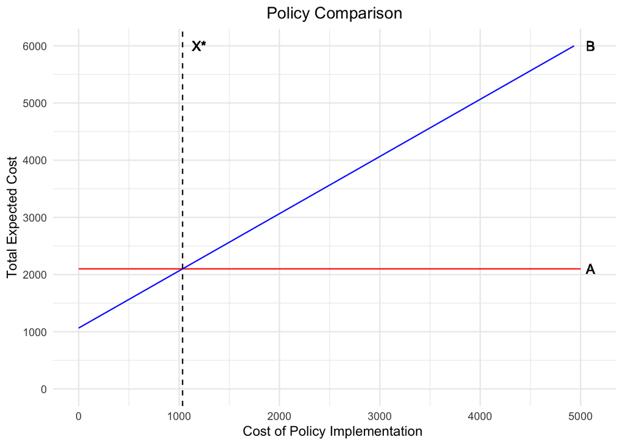

```r
ggplot(data = cost_df) +
 geom_line(aes(x = cost/1e12, y = cost_policy_a/1e12), color = "red") +
  geom_line(aes(x = cost/1e12, y = cost_policy_b/1e12), color = "blue") +
  scale_y_continuous(limits = c(0, 6000), n.breaks = 6) +
  scale_x_continuous(limits = c(0, 5100), n.breaks = 5) +
  geom_text(aes(x = 5100, y = 2100, label = "A")) +
  geom_text(aes(x = 5100, y = 6000, label = "B")) +
  geom_text(aes(x = 1200, y = 6000, label = "X*")) +
  geom_vline(xintercept = intercept/1e12, linetype = "dashed") +
  labs(title = "Policy Comparison", x = "Cost of Policy Implementation ", y = "Total Expected Cost") +
  theme_minimal() +
  theme(plot.title = element_text(hjust = 0.5))
```

**Figure 5.** Cost of Policy Impmentation versus the Expected Total Cost for Policy A (red) and B (blue). X* represents the intercept and the inflection point where **below X*, Policy B is preferred, but above X, Policy A is preferred**. However, unless the implementation costs are greater than X = $1.03 x10^{15}$ dollars, Congress should implement Policy B.

## Question 6.

#### Now suppose that society is risk averse. How do you think this would change your advice to Congress?

Given that society is risk averse, the certainty of Policy B is a more likely choice than the uncertainty related with Policy A. Policy A has a chance of reducing overall damages more dramatically than Policy B, however, there is a 50% chance that it will actually result in higher damages. Given this, it is recommended that Congress pursue Policy B, as it will certainly reduce emissions, and it is in line with the risk averse society in which we live.